# 5-3. Visualize correlation matrix using correlogram

### 7. Types of correlogram layout

- There are three types of layout :
  - `full` (default) : display full correlation matrix
  - `upper` : display upper triangular of the correlation matrix
  - `lower` : display lower triangular of the correlation matrix

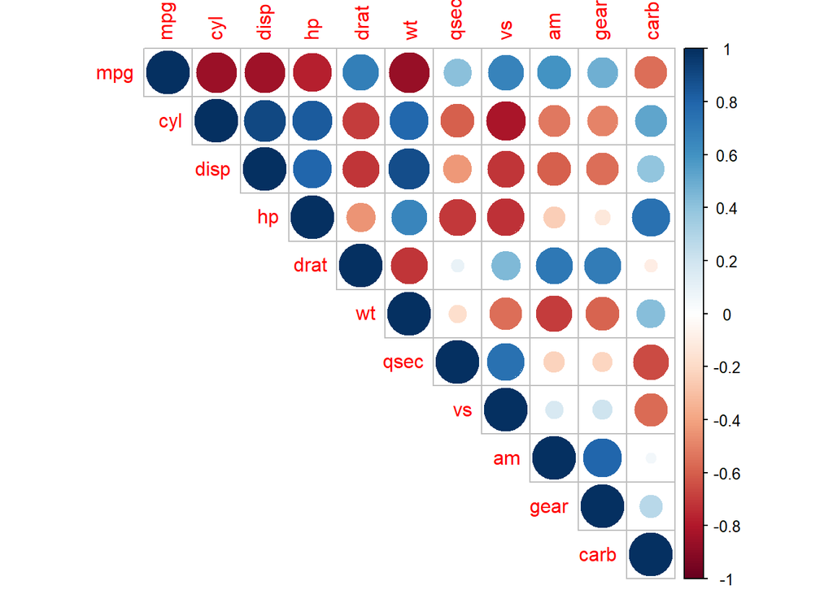

```r
corrplot(M, type="upper")
```

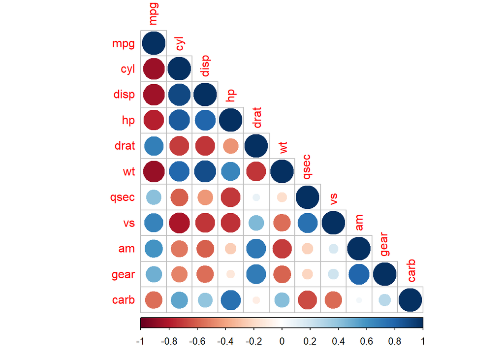

```r
corrplot(M, type="lower")
```

### 8. Reordering the correlation matrix

- The correlation matrix can be reordered according to the correlation coefficient.
- This is important to identify the hidden structure and pattern in the matrix.
- `hclust` for hierarchical clustering order is used in the following examples.

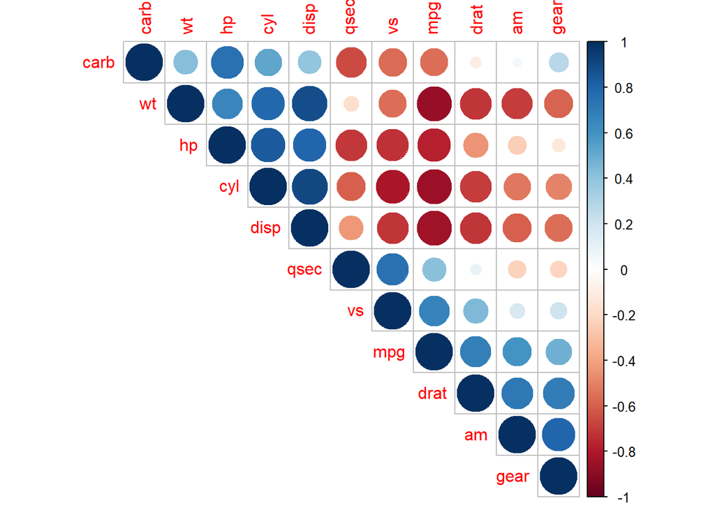

```r
# correlogram with "hclust" reordering
corrplot(M, type="upper", order="hclust")
```

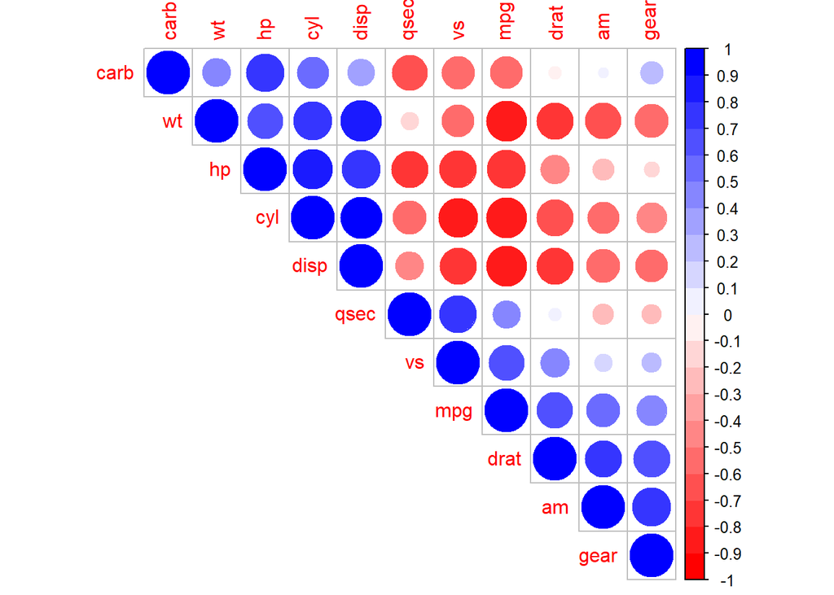

```r
# Using different color spectrum
col<- colorRampPalette(c("red", "white", "blue"))(20)
corrplot(M, type="upper", order="hclust", col=col)
```

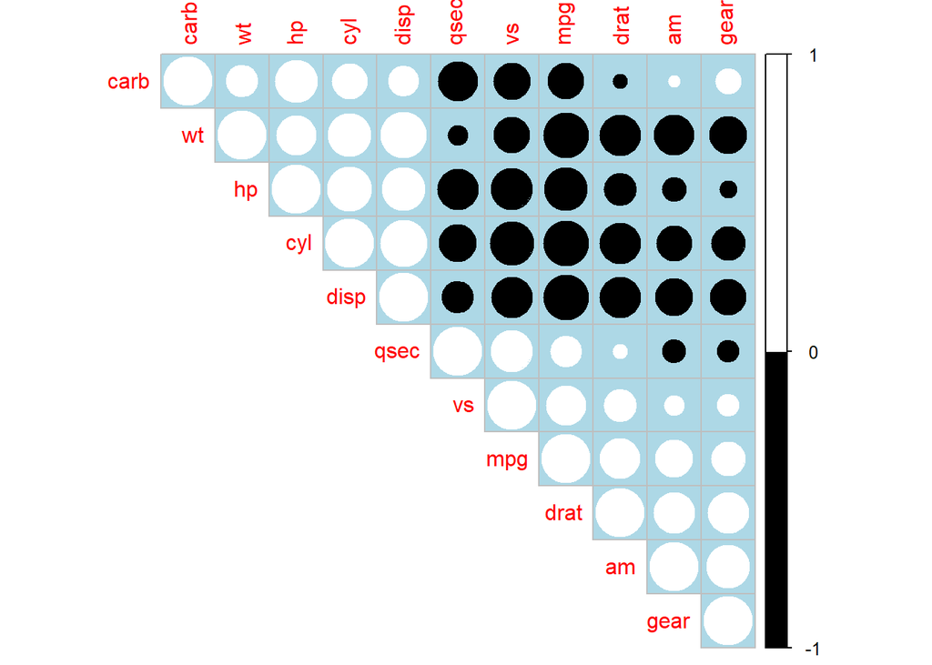

```r
# Change background color to lightblue
corrplot(M, type="upper", order="hclust", col=c("black", "white"), bg="lightblue")
```

### 9. Changing the color of the correlogram

- As shown in the above section, the color of the `correlogram` can be customized.
- `RcolorBrewer` palette of colors are used in the R script below :

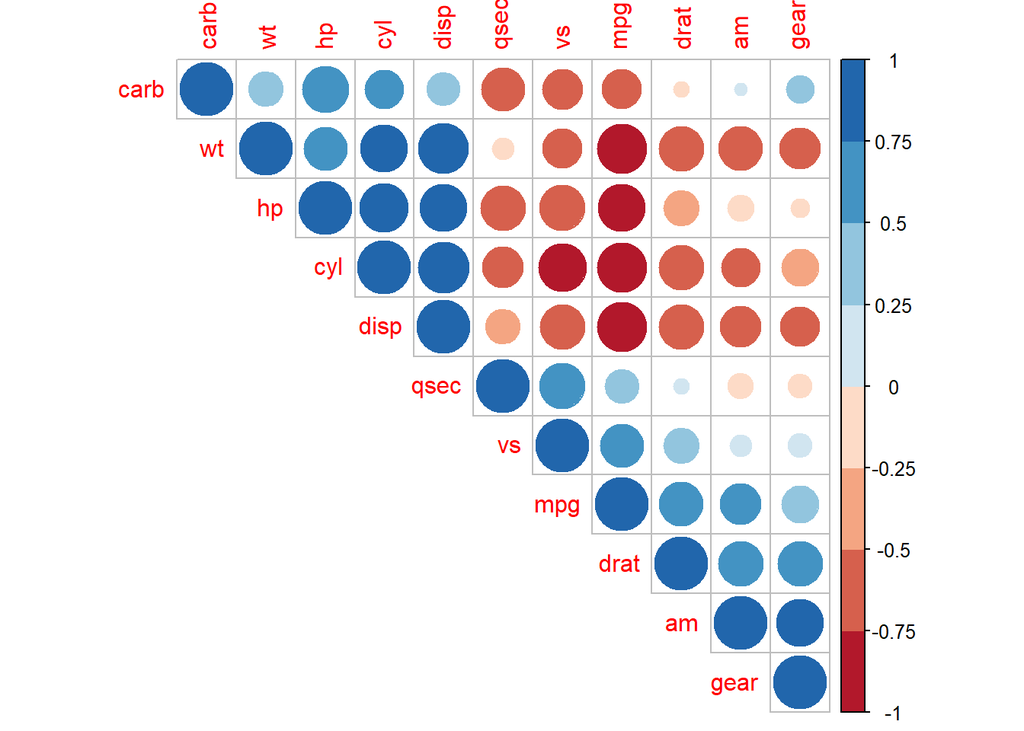

```r
library(RColorBrewer, quietly = TRUE)

# brewer.pal{RColorBrewer} : ColorBrewer palettes
# Creates nice looking color palettes especially for thematic maps
corrplot(M, type="upper", order="hclust", col=brewer.pal(n=8, name="RdBu" ))
```

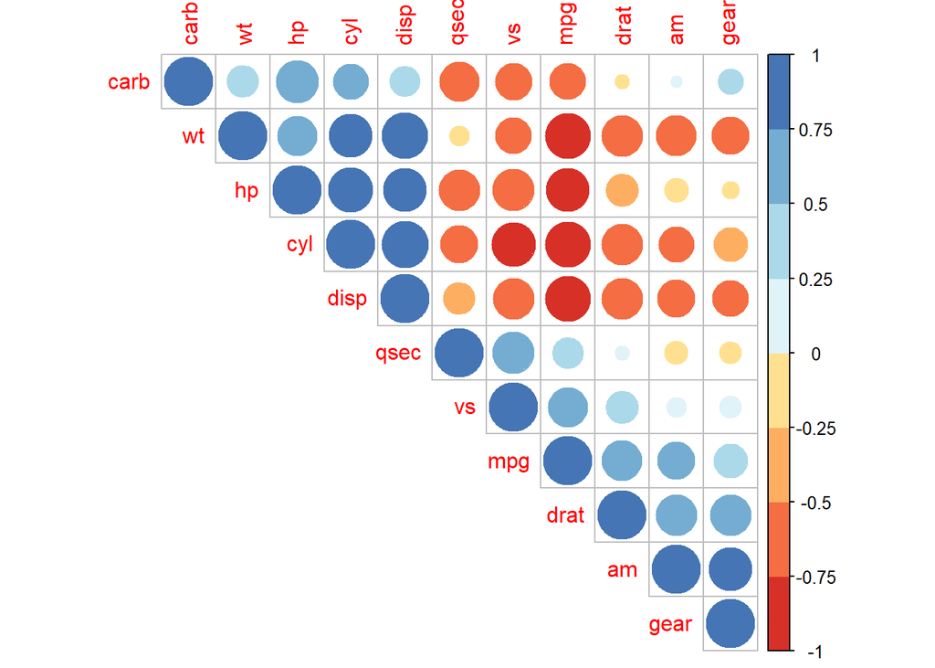

```r
corrplot(M, type="upper", order="hclust", col=brewer.pal(n=8, name="RdYlBu"))
```

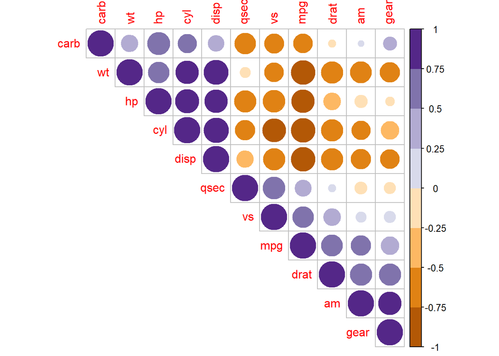

```r
corrplot(M, type="upper", order="hclust", col=brewer.pal(n=8, name="PuOr"))
```

### 10. Changing the color and the rotation of text labels

- `tl.col` (for text label color) and `tl.srt` (for text label string rotation) are used to change text colors and rotations.

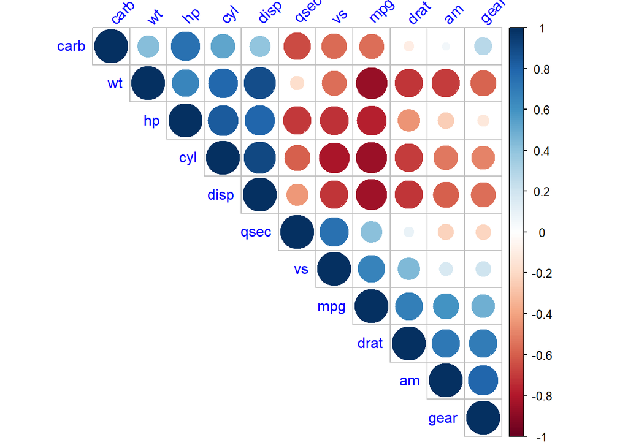

```r
corrplot(M, type="upper", order="hclust", tl.col="blue", tl.srt=45)
```

### 11. Combining correlogram with the significance test

- Computing the p-value of correlations
  - To compute the matrix of p-value, a custom R function is used :

```r
# mat : is a matrix of data
# ... : further arguments to pass to the native R cor.test{stats} function
cor.mtest <- function(mat, ...) {
    mat <- as.matrix(mat)
    n <- ncol(mat)
    p.mat<- matrix(NA, n, n)
    diag(p.mat) <- 0

    for (i in 1:(n - 1)) {
        for (j in (i + 1):n) {
            tmp <- cor.test(mat[, i], mat[, j], ...)
            p.mat[i, j] <- p.mat[j, i] <- tmp$p.value
        }
    }

    colnames(p.mat) <- rownames(p.mat) <- colnames(mat)
    p.mat
} # end function

# matrix of the p-value of the correlation
p.mat <- cor.mtest(mtcars)

head(p.mat[, 1:5])
```

```
##               mpg          cyl         disp           hp         drat
## mpg  0.000000e+00 6.112687e-10 9.380327e-10 1.787835e-07 1.776240e-05
## cyl  6.112687e-10 0.000000e+00 1.802838e-12 3.477861e-09 8.244636e-06
## disp 9.380327e-10 1.802838e-12 0.000000e+00 7.142679e-08 5.282022e-06
## hp   1.787835e-07 3.477861e-09 7.142679e-08 0.000000e+00 9.988772e-03
## drat 1.776240e-05 8.244636e-06 5.282022e-06 9.988772e-03 0.000000e+00
## wt   1.293959e-10 1.217567e-07 1.222320e-11 4.145827e-05 4.784260e-06
```

- Add significance level to the `correlogram`
- In the below figure,
  - correlations with p-value > 0.01 are considered as insignificant.
  - In this case, the correlation coefficient values are leaved blank or crosses are added.

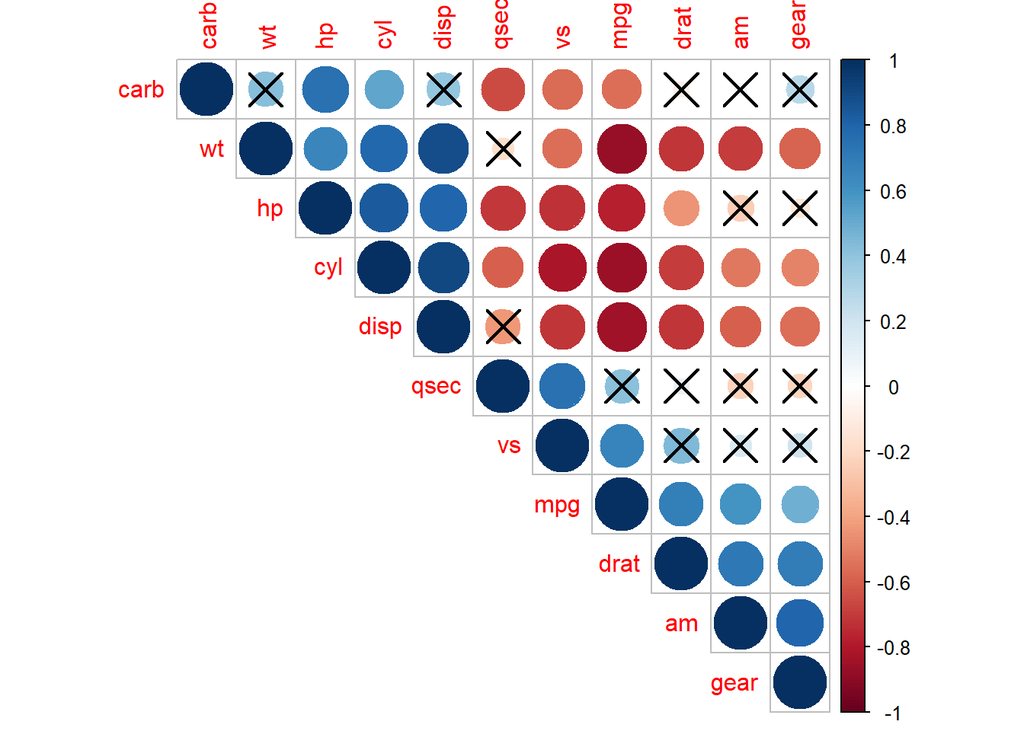

```r
# Specialized the insignificant value according to the significant level
corrplot(M, type="upper", order="hclust", p.mat = p.mat, sig.level = 0.01)
```

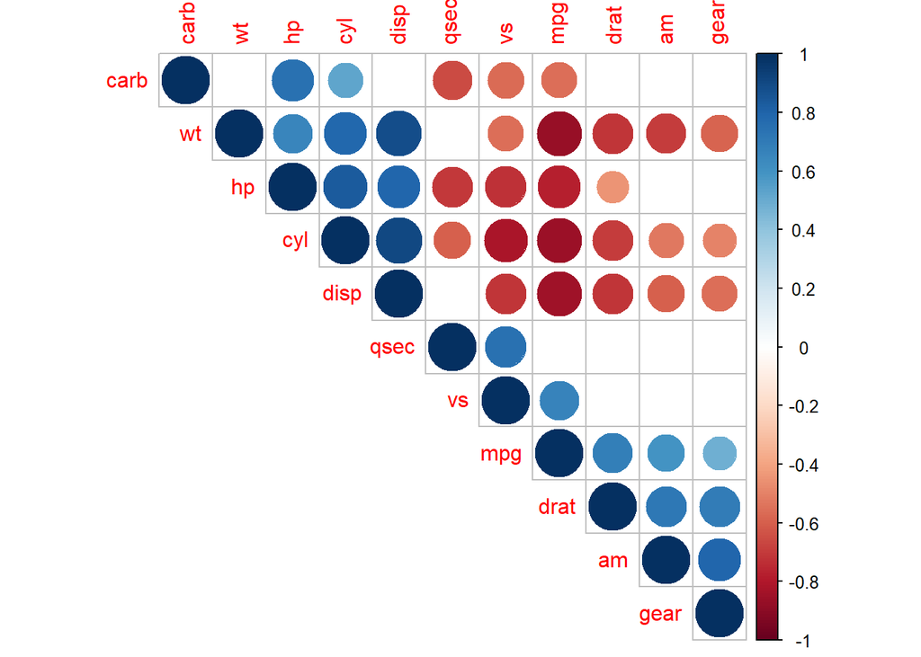

```r
# Leave blank on no significant coefficient
corrplot(M, type="upper", order="hclust", p.mat = p.mat, sig.level = 0.01, insig = "blank")
```

### 12. Customize the correlogram

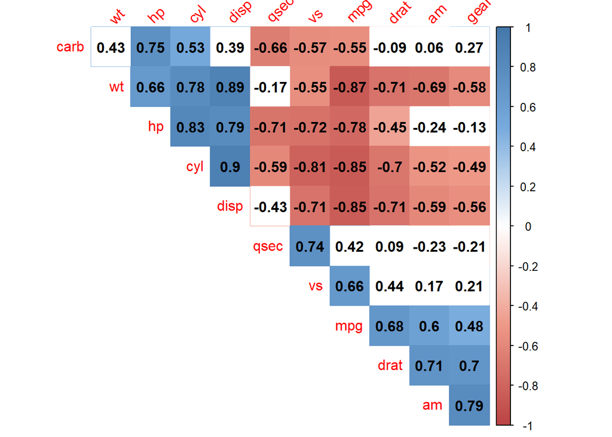

```r
col <- colorRampPalette(c("#BB4444", "#EE9988", "#FFFFFF", "#77AADD", "#4477AA"))

corrplot(
      M,
      method="color",
      col=col(200),
      type="upper",
      order="hclust",
      # Add coefficient of correlation
      addCoef.col = "black",
      #Text label color and rotation
      tl.col="red",
      tl.srt=45,
      # Combine with significance
      p.mat = p.mat,
      sig.level = 0.01,
      insig = "blank",
      # hide correlation coefficient on the principal diagonal
      diag=FALSE
  )
```

### 13. Conclusions

- Use `corrplot{corrplot}` function to plot an elegant graph of a correlation matrix.